# Analysis of longitudinal data

Shweta Goswami

08-12-2018

# Analysis of Longitudinal Data

According to the instructions, the dataset has been swapped. The current analysis includes Chapter 8 of MABS using the RATS data and Chapter 9 of MABS using the BPRS data.

### **Interpretation of the wide and long form data**

If we compare wide and long form of data, the wide form combines one of the keys with the value variables and their columns represent groups. The wide data has multiple columns for outcomes as we can see in RATS and BPRS original dataset. The long form data presents each subject’s response in multiple rows and every row shows a response/observation that belongs to a particular variable. In simple terms, the long form represents columns of outcomes into a single response variable as evident in BPRSL and RATSL dataset. For the regression and ggplot functions, long form data is preferred.

## Analysis of RATS data

The RATS data in the current analysis is based on a nutrition study conducted in three groups of rats. Those three groups were put on different diets. Each rat’s body weight in grams was recorded approximately on a weekly basis, except in week seven when two recordings were observed over a 9-week period.

Question: Whether the growth profiles of the three groups differ?

Hypothesis: The growth profiles of three groups of rats differs with time.

### **Overview of RATSL (long form) data**

```
##   ID Group  WD Weight Time
## 1  1     1 WD1    240    1
## 2  2     1 WD1    225    1
## 3  3     1 WD1    245    1
## 4  4     1 WD1    260    1
## 5  5     1 WD1    255    1
## 6  6     1 WD1    260    1
```

```
##        ID      Group       WD                Weight           Time
##  1      : 11   1:88   Length:176         Min.   :225.0   Min.   : 1.00
##  2      : 11   2:44   Class :character   1st Qu.:267.0   1st Qu.:15.00
##  3      : 11   3:44   Mode  :character   Median :344.5   Median :36.00
##  4      : 11                             Mean   :384.5   Mean   :33.55
##  5      : 11                             3rd Qu.:511.2   3rd Qu.:50.00
##  6      : 11                             Max.   :628.0   Max.   :64.00
##  (Other):110
```

```
## Observations: 176
## Variables: 5
## $ ID     <fct> 1, 2, 3, 4, 5, 6, 7, 8, 9, 10, 11, 12, 13, 14, 15, 16, ...
## $ Group  <fct> 1, 1, 1, 1, 1, 1, 1, 1, 2, 2, 2, 2, 3, 3, 3, 3, 1, 1, 1...
## $ WD     <chr> "WD1", "WD1", "WD1", "WD1", "WD1", "WD1", "WD1", "WD1",...
## $ Weight <int> 240, 225, 245, 260, 255, 260, 275, 245, 410, 405, 445, ...
## $ Time   <int> 1, 1, 1, 1, 1, 1, 1, 1, 1, 1, 1, 1, 1, 1, 1, 1, 8, 8, 8...
```

The original data was in the wide form and had 16 obs. of 13 variables. After reshaping the data to long form, it has 176 obs. of 5 variables. The five variables are “ID”, “Group”, “WD”, “Weight” and “Time”. The minimum and maximum weight observed is 225 and 628 grams respectively. The time is observed in days ranging from 1-64.

### **Graphical overview of RATSL data**

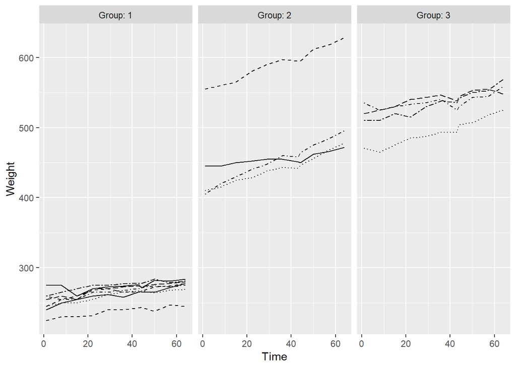

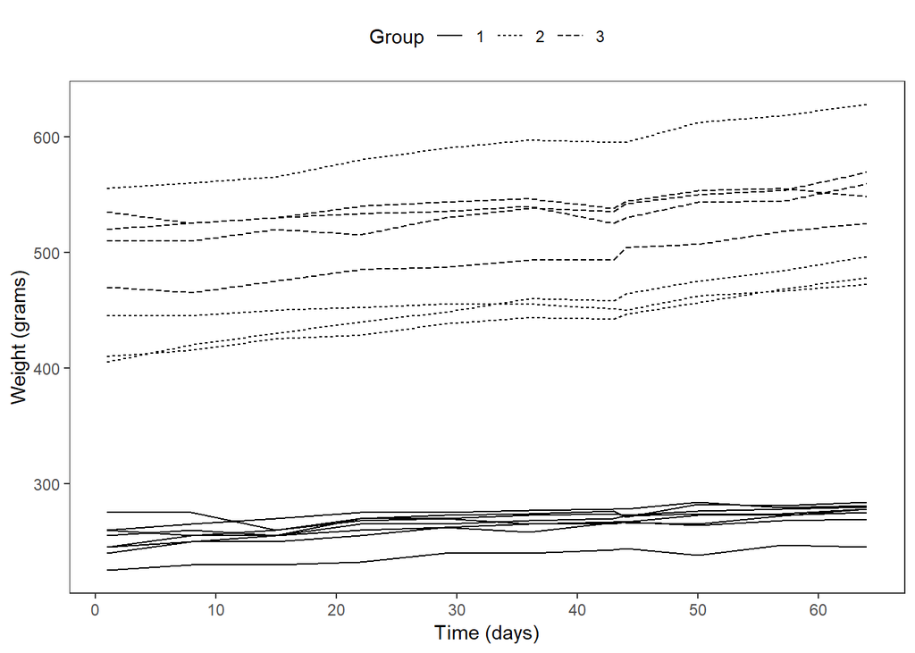

### **Graphical overview after standardization**

```
## Observations: 176
## Variables: 6
## $ ID        <fct> 1, 2, 3, 4, 5, 6, 7, 8, 9, 10, 11, 12, 13, 14, 15, 1...
## $ Group     <fct> 1, 1, 1, 1, 1, 1, 1, 1, 2, 2, 2, 2, 3, 3, 3, 3, 1, 1...
## $ WD        <chr> "WD1", "WD1", "WD1", "WD1", "WD1", "WD1", "WD1", "WD...
## $ Weight    <int> 240, 225, 245, 260, 255, 260, 275, 245, 410, 405, 44...
## $ Time      <int> 1, 1, 1, 1, 1, 1, 1, 1, 1, 1, 1, 1, 1, 1, 1, 1, 8, 8...
## $ stdweight <dbl> -1.73263452, -2.82850303, -1.36734502, -0.27147652, ...
```

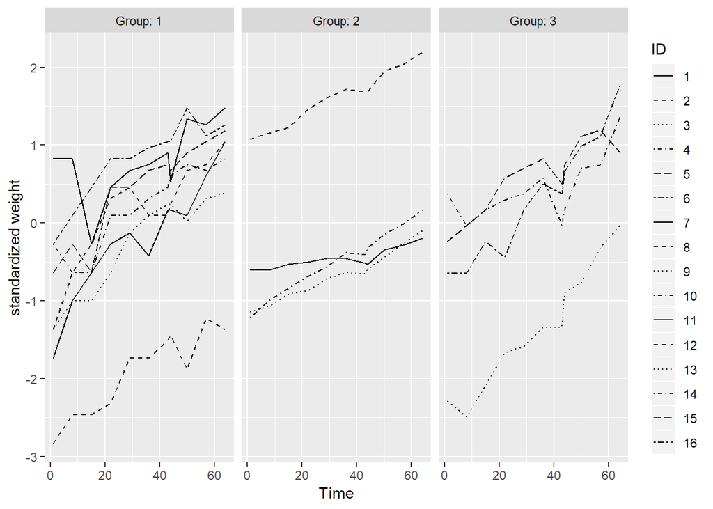

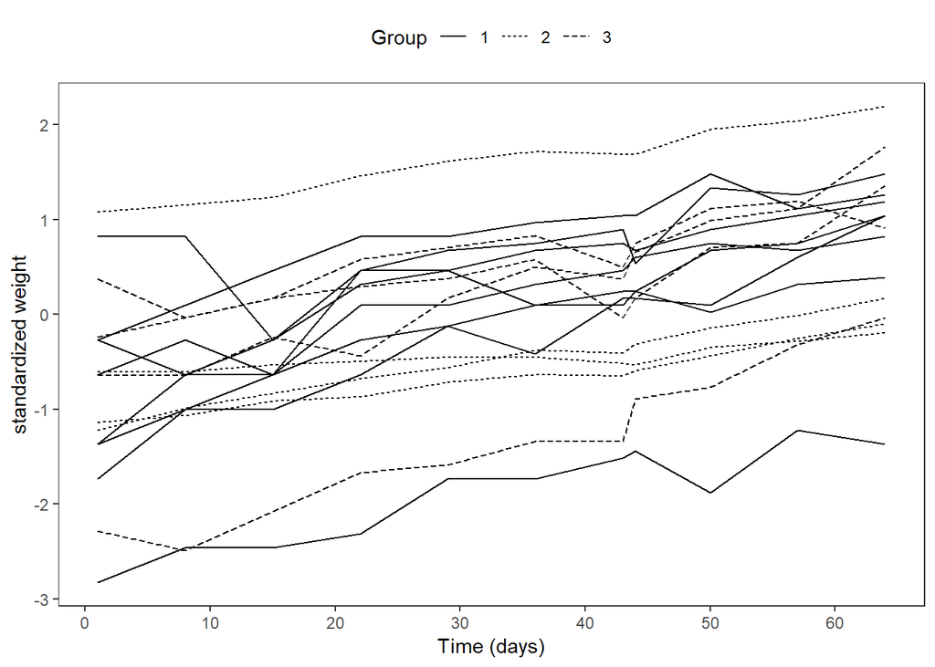

### **Plotting the mean profiles**

```
## Observations: 33
## Variables: 4
## $ Group <fct> 1, 1, 1, 1, 1, 1, 1, 1, 1, 1, 1, 2, 2, 2, 2, 2, 2, 2, 2,...
## $ Time  <int> 1, 8, 15, 22, 29, 36, 43, 44, 50, 57, 64, 1, 8, 15, 22, ...
## $ mean  <dbl> 250.625, 255.000, 254.375, 261.875, 264.625, 265.000, 26...
## $ se    <dbl> 4.589478, 3.947710, 3.460116, 4.100800, 3.333956, 3.5529...
```

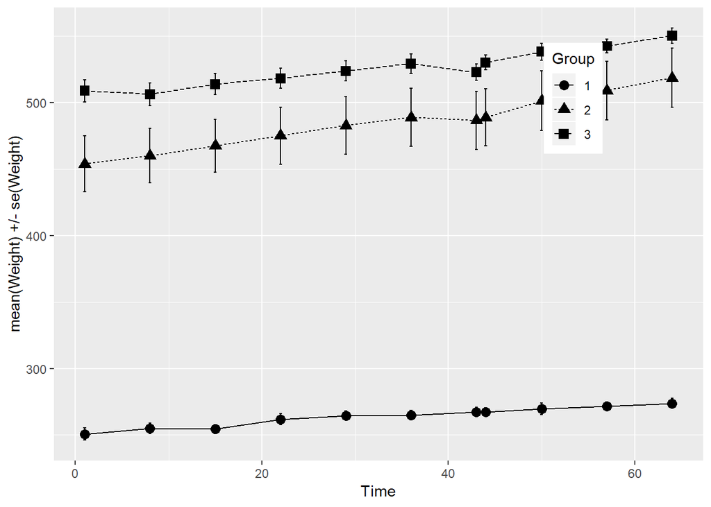

The graph mentioned above shows average profiles for three groups of rats along with some indication of the variation of the observations at each time point. There seems to be no overlap in the mean profiles of the three groups of rats suggesting that there is obvious difference between the three groups with respect to the mean weight profile.

### **Creating plot to check the outlier**

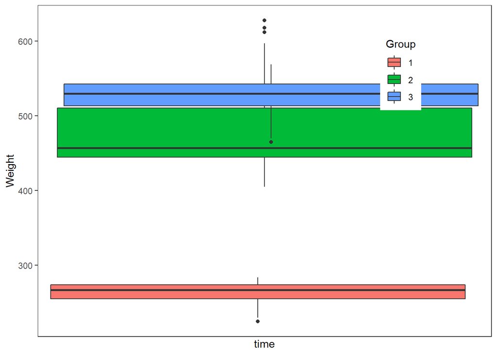

### **Creating boxplot of the mean vs group to check the outlier**

```
## Observations: 16
## Variables: 3
## $ Group <fct> 1, 1, 1, 1, 1, 1, 1, 1, 2, 2, 2, 2, 3, 3, 3, 3
## $ ID    <fct> 1, 2, 3, 4, 5, 6, 7, 8, 9, 10, 11, 12, 13, 14, 15, 16
## $ mean  <dbl> 261.0909, 237.6364, 260.1818, 266.5455, 269.4545, 274.72...
```

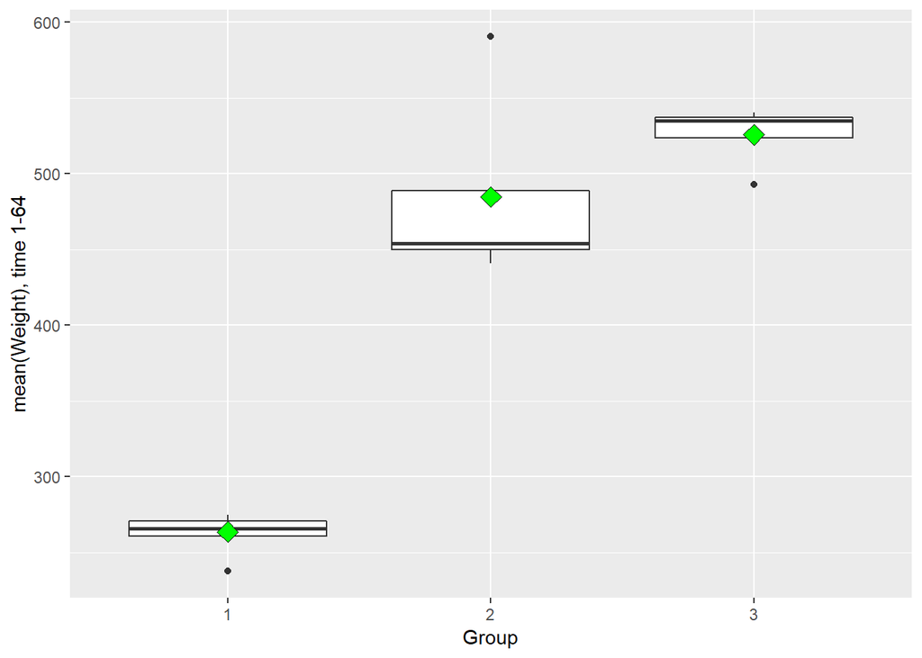

The mean summary measure of the second group of rats shows more variation as compared to the other two groups. The boxplot of the second group shows an outlier whose mean weight is around 600. To avoid bias in further analyses, the outlier present in the second group will be removed.

### **Filtering the outlier, adjusting the ggplot code the drawing the plot again**

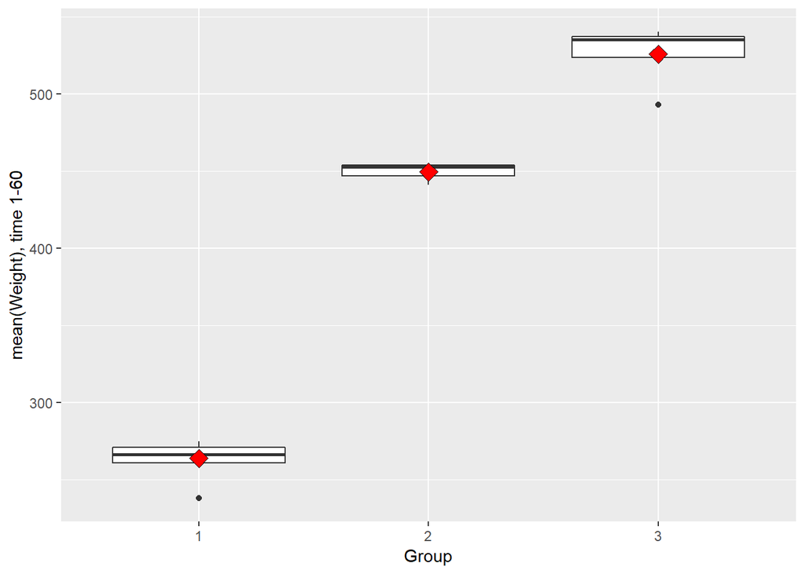

The boxplot mentioned above is without the outlier with respect to the second group and shows clear difference in location of the summary measure distributions in each group.

All the graphs mentioned above clearly indicates difference in the three groups of rats. To be certain, ANOVA will be taken into consideration.

### **Analysis of Variance with outliers**

```
## Analysis of Variance Table
##
## Response: mean
##           Df Sum Sq Mean Sq F value    Pr(>F)
## Group      2 236732  118366  88.073 2.763e-08 ***
## Residuals 13  17471    1344
## ---
## Signif. codes:  0 '***' 0.001 '**' 0.01 '*' 0.05 '.' 0.1 ' ' 1
```

### **Analysis of Variance after filtering outliers from Group 2**

```
## Analysis of Variance Table
##
## Response: mean
##           Df Sum Sq Mean Sq F value    Pr(>F)
## Group      2 206390  103195   483.6 3.387e-12 ***
## Residuals 12   2561     213
## ---
## Signif. codes:  0 '***' 0.001 '**' 0.01 '*' 0.05 '.' 0.1 ' ' 1
```

The objective of the ANOVA test is to analyse if there is a (statistically) significant difference in weight growth between different groups. It is going to compare means of response among the different groups and check if differences are statistically significant. Two hypothesis are there in ANOVA:

*Null Hypothesis: All group means are equal and there is no difference among them.

*Alternative Hypothesis: All group means are NOT equal and there is difference among the three groups under observation.

The larger the F value, the greater the relative variance among the group means. The F-value including outliers and without outliers is 88.07 and 483.6 resp which shows the great relative variance among groups. The p-value is also less than 0.05 suggesting the differences among group statistically significant.

## Analysis of BPRS data

The second part of the analysis is based on BPRS data which constitutes 40 male subjects that were randomly assigned to one of two treatment groups. The subjects were rated on the Brief Psychiatric Rating Scale (BPRS). They were measured before treatment began i.e.week 0 and then at weekly intervals for eight weeks.

The BPRS score shows the level of 18 symptom constructs, for instance, hostility, suspiciousness, hallucinations and grandiosity. The scale is rated from one (not present) to seven (extremely severe) and is used to investigate patients suspected of having schizophrenia.

Hypothesis: The BPRS score of the subjects decreases over the eight weeks of the study.

### **Overview of BPRSL (long form) data**

```
##   treatment subject weeks bprs week
## 1         1       1 week0   42    0
## 2         1       2 week0   58    0
## 3         1       3 week0   54    0
## 4         1       4 week0   55    0
## 5         1       5 week0   72    0
## 6         1       6 week0   48    0
```

```
## Observations: 360
## Variables: 5
## $ treatment <fct> 1, 1, 1, 1, 1, 1, 1, 1, 1, 1, 1, 1, 1, 1, 1, 1, 1, 1...
## $ subject   <fct> 1, 2, 3, 4, 5, 6, 7, 8, 9, 10, 11, 12, 13, 14, 15, 1...
## $ weeks     <chr> "week0", "week0", "week0", "week0", "week0", "week0"...
## $ bprs      <int> 42, 58, 54, 55, 72, 48, 71, 30, 41, 57, 30, 55, 36, ...
## $ week      <int> 0, 0, 0, 0, 0, 0, 0, 0, 0, 0, 0, 0, 0, 0, 0, 0, 0, 0...
```

```
##  treatment    subject       weeks                bprs            week
##  1:180     1      : 18   Length:360         Min.   :18.00   Min.   :0
##  2:180     2      : 18   Class :character   1st Qu.:27.00   1st Qu.:2
##            3      : 18   Mode  :character   Median :35.00   Median :4
##            4      : 18                      Mean   :37.66   Mean   :4
##            5      : 18                      3rd Qu.:43.00   3rd Qu.:6
##            6      : 18                      Max.   :95.00   Max.   :8
##            (Other):252
```

The original data was in the wide form and had 40 obs. of 11 variables. After reshaping the data to long form, it has 360 obs. of 5 variables. The five variables are “treatment”, “subject”, “weeks”, “bprs” and “week”. The minimum and maximum bprs observed is 18 and 95 respectively. The time is observed in weeks ranging from 0-8.

### **Plotting the BPRSL data**

Plot of bprs score against time (week) for BPRS data

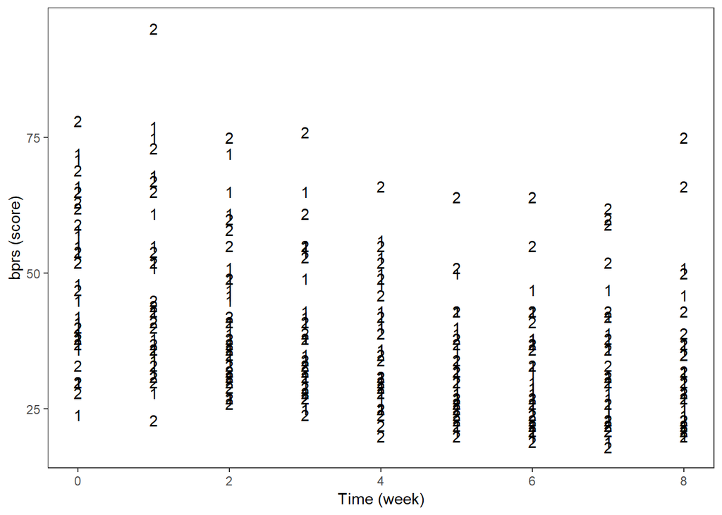

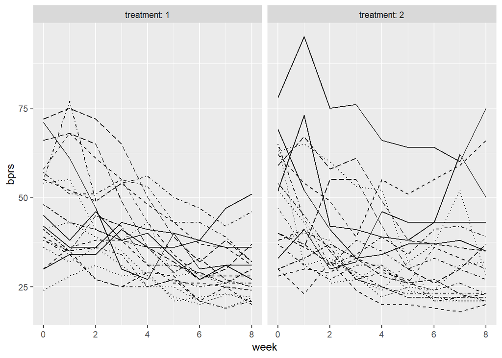

There seems to be overlapping between two treatments in the first plot. In the second plot, there seems to have decreasing trend in bprs score over the 8 weeks of time.

### **Creating a regression model**

```
##
## Call:
## lm(formula = bprs ~ week + treatment, data = BPRSL)
##
## Residuals:
##     Min      1Q  Median      3Q     Max
## -22.454  -8.965  -3.196   7.002  50.244
##
## Coefficients:
##             Estimate Std. Error t value Pr(>|t|)
## (Intercept)  46.4539     1.3670  33.982   <2e-16 ***
## week         -2.2704     0.2524  -8.995   <2e-16 ***
## treatment2    0.5722     1.3034   0.439    0.661
## ---
## Signif. codes:  0 '***' 0.001 '**' 0.01 '*' 0.05 '.' 0.1 ' ' 1
##
## Residual standard error: 12.37 on 357 degrees of freedom
## Multiple R-squared:  0.1851, Adjusted R-squared:  0.1806
## F-statistic: 40.55 on 2 and 357 DF,  p-value: < 2.2e-16
```

```
##               Estimate Std. Error    t value      Pr(>|t|)
## (Intercept) 46.4538889  1.3670163 33.9819579 6.256351e-114
## week        -2.2704167  0.2524021 -8.9952367  1.412930e-17
## treatment2   0.5722222  1.3033989  0.4390231  6.609104e-01
```

A multiple linear regression model is fitted with bprs score as response variable and week and treatment as explanatory variables.

Tt can be seen that p-value of the F-statistic is < 2.2e-16, which is highly significant. It suggests that one of the explanatory variables is significantly related to the outcome variable.

The coefficient shows the amount of changes in the response variable when independent variables change one unit. With every increase in the variable week, the bprs score will decrease significantly.

### **Random intercept model for the same two explanatory variables**

```
## Linear mixed model fit by maximum likelihood  ['lmerMod']
## Formula: bprs ~ week + treatment + (1 | subject)
##    Data: BPRSL
##
##      AIC      BIC   logLik deviance df.resid
##   2748.7   2768.1  -1369.4   2738.7      355
##
## Scaled residuals:
##     Min      1Q  Median      3Q     Max
## -3.0481 -0.6749 -0.1361  0.4813  3.4855
##
## Random effects:
##  Groups   Name        Variance Std.Dev.
##  subject  (Intercept)  47.41    6.885
##  Residual             104.21   10.208
## Number of obs: 360, groups:  subject, 20
##
## Fixed effects:
##             Estimate Std. Error t value
## (Intercept)  46.4539     1.9090  24.334
## week         -2.2704     0.2084 -10.896
## treatment2    0.5722     1.0761   0.532
##
## Correlation of Fixed Effects:
##            (Intr) week
## week       -0.437
## treatment2 -0.282  0.000
```

The variance in random factor tells how much variability there is between subjects across the treatments. The estimated variance of the bprs random effects is 47.41, indicating variation in the intercepts of the regression fits of the subject’s bprs scores. The regression parameters for week and the treatment2 (treatment1 as reference) are similar to those in the previous regression model. The estimated standard error of treatment2 is slightly smaller than the previous regression model whereas it is almost similar with respect to week. Overall, the previous regression model and the random intercept model shows almost similar results.

### **Random intercept and random slope model**

```
## Linear mixed model fit by maximum likelihood  ['lmerMod']
## Formula: bprs ~ week + treatment + (week | subject)
##    Data: BPRSL
##
##      AIC      BIC   logLik deviance df.resid
##   2745.4   2772.6  -1365.7   2731.4      353
##
## Scaled residuals:
##     Min      1Q  Median      3Q     Max
## -2.8919 -0.6194 -0.0691  0.5531  3.7976
##
## Random effects:
##  Groups   Name        Variance Std.Dev. Corr
##  subject  (Intercept) 64.8202  8.0511
##           week         0.9608  0.9802   -0.51
##  Residual             97.4307  9.8707
## Number of obs: 360, groups:  subject, 20
##
## Fixed effects:
##             Estimate Std. Error t value
## (Intercept)  46.4539     2.1052  22.066
## week         -2.2704     0.2977  -7.626
## treatment2    0.5722     1.0405   0.550
##
## Correlation of Fixed Effects:
##            (Intr) week
## week       -0.582
## treatment2 -0.247  0.000
```

### **ANOVA test on two models (BPRS_ref, BPRS_ref1)**

```
## Data: BPRSL
## Models:
## BPRS_ref: bprs ~ week + treatment + (1 | subject)
## BPRS_ref1: bprs ~ week + treatment + (week | subject)
##           Df    AIC    BIC  logLik deviance  Chisq Chi Df Pr(>Chisq)
## BPRS_ref   5 2748.7 2768.1 -1369.4   2738.7
## BPRS_ref1  7 2745.4 2772.6 -1365.7   2731.4 7.2721      2    0.02636 *
## ---
## Signif. codes:  0 '***' 0.001 '**' 0.01 '*' 0.05 '.' 0.1 ' ' 1
```

This is to test regression significance. The likelihood ratio test for the random intercept model versus the random intercept and slope model gives a chi-squared statistic of 7.27 with 2 degrees of freedom the associated p-value is also significant. The random intercept and slope model provides a better fit for the BPRS data.

### **Random Intercept and Random Slope Model with interaction**

```
## Linear mixed model fit by maximum likelihood  ['lmerMod']
## Formula: bprs ~ week * treatment + (week | subject)
##    Data: BPRSL
##
##      AIC      BIC   logLik deviance df.resid
##   2744.3   2775.4  -1364.1   2728.3      352
##
## Scaled residuals:
##     Min      1Q  Median      3Q     Max
## -3.0512 -0.6271 -0.0767  0.5288  3.9260
##
## Random effects:
##  Groups   Name        Variance Std.Dev. Corr
##  subject  (Intercept) 65.0016  8.0624
##           week         0.9688  0.9843   -0.51
##  Residual             96.4699  9.8219
## Number of obs: 360, groups:  subject, 20
##
## Fixed effects:
##                 Estimate Std. Error t value
## (Intercept)      47.8856     2.2522  21.262
## week             -2.6283     0.3589  -7.323
## treatment2       -2.2911     1.9090  -1.200
## week:treatment2   0.7158     0.4010   1.785
##
## Correlation of Fixed Effects:
##             (Intr) week   trtmn2
## week        -0.650
## treatment2  -0.424  0.469
## wek:trtmnt2  0.356 -0.559 -0.840
```

Fitting a random intercept and slope model that allows for a week × treatment interaction.

The estimated regression parameters shows the interaction between week and treatment (0.71). To see the regression significance, let’s do ANOVA test again.

### **ANOVA test on two models (BPRS_ref2, BPRS_ref1)**

```
## Data: BPRSL
## Models:
## BPRS_ref1: bprs ~ week + treatment + (week | subject)
## BPRS_ref2: bprs ~ week * treatment + (week | subject)
##           Df    AIC    BIC  logLik deviance  Chisq Chi Df Pr(>Chisq)
## BPRS_ref1  7 2745.4 2772.6 -1365.7   2731.4
## BPRS_ref2  8 2744.3 2775.4 -1364.1   2728.3 3.1712      1    0.07495 .
## ---
## Signif. codes:  0 '***' 0.001 '**' 0.01 '*' 0.05 '.' 0.1 ' ' 1
```

### **Plotting fitted values of BPRSL**

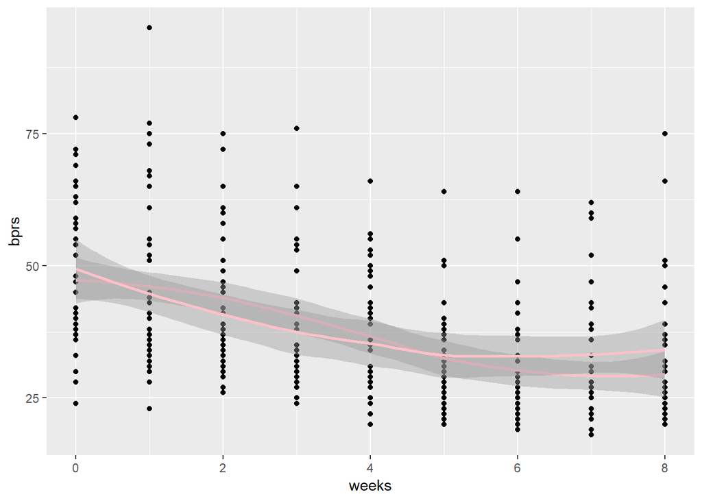

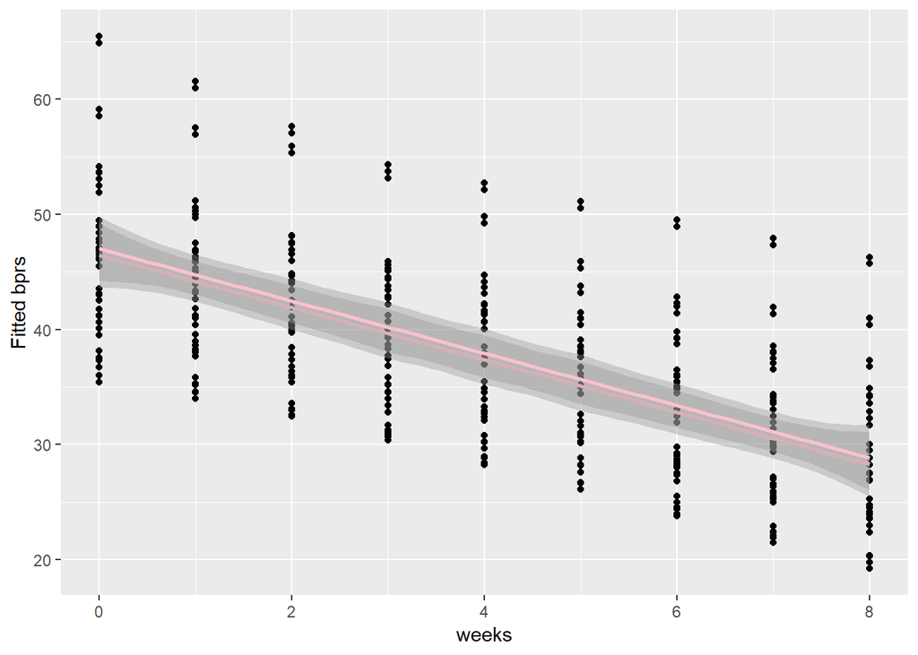

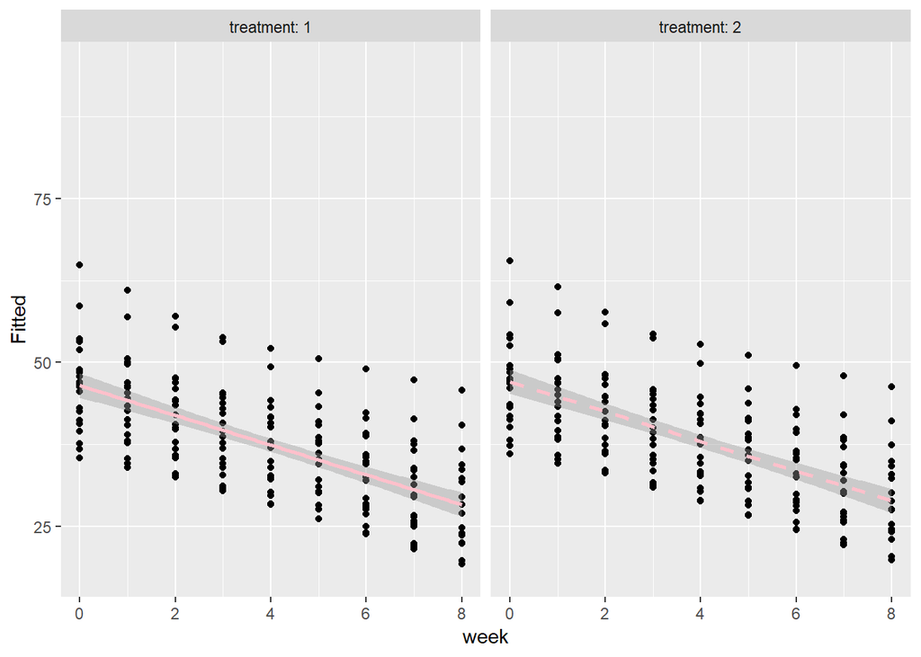

The graph shows almost similar decreasing trend in both treatment 1 & 2.